# DATA MINIPULATION WITH DPLYR: TRANSFORMING DATA

### 1.1 The Counties dataset

Load `tidyverse` including the `dplyr` package:

```r
library(tidyverse)
```

Import the `counties` dataset in form of `.rds` file in `0_data`:

```r
counties <- readRDS("counties.rds")
```

This is a big dataset which contains the result of 2015 US Census. A state is one of 50 regions within the US. A county is a subregion of one of those states, like Los Angeles county of California state.

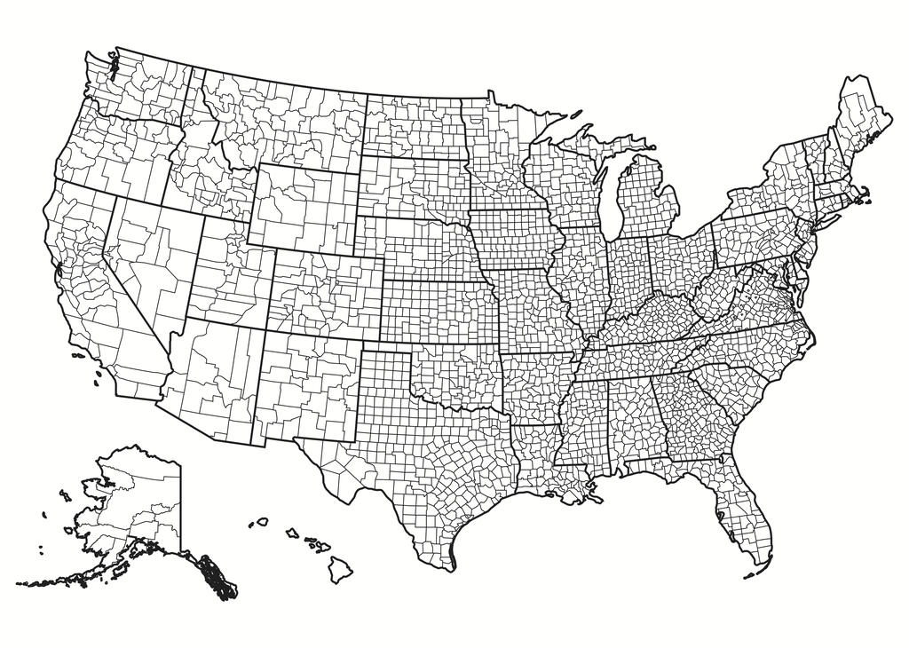

See a few values from all the columns:

```r
glimpse(counties)
```

```
## Rows: 3,138
## Columns: 40
## $ census_id          <chr> "1001", "1003", "1005", "1007", "1009", "1011", ...
## $ state              <chr> "Alabama", "Alabama", "Alabama", "Alabama", "Ala...
## $ county             <chr> "Autauga", "Baldwin", "Barbour", "Bibb", "Blount...
## $ region             <chr> "South", "South", "South", "South", "South", "So...
## $ metro              <chr> "Metro", "Metro", "Nonmetro", "Metro", "Metro", ...
## $ population         <dbl> 55221, 195121, 26932, 22604, 57710, 10678, 20354...
## $ men                <dbl> 26745, 95314, 14497, 12073, 28512, 5660, 9502, 5...
## $ women              <dbl> 28476, 99807, 12435, 10531, 29198, 5018, 10852, ...
## $ hispanic           <dbl> 2.6, 4.5, 4.6, 2.2, 8.6, 4.4, 1.2, 3.5, 0.4, 1.5...
## $ white              <dbl> 75.8, 83.1, 46.2, 74.5, 87.9, 22.2, 53.3, 73.0, ...
## $ black              <dbl> 18.5, 9.5, 46.7, 21.4, 1.5, 70.7, 43.8, 20.3, 40...
## $ native             <dbl> 0.4, 0.6, 0.2, 0.4, 0.3, 1.2, 0.1, 0.2, 0.2, 0.6...
## $ asian              <dbl> 1.0, 0.7, 0.4, 0.1, 0.1, 0.2, 0.4, 0.9, 0.8, 0.3...
```

[output cut: 27 more lines]

### 1.2 select()

`select()` extracts only a few variables from the dataset.

```r
counties %>%
  select(state, county, population, unemployment)
```

```
## # A tibble: 3,138 x 4
##    state   county   population unemployment
##    <chr>   <chr>         <dbl>        <dbl>
##  1 Alabama Autauga       55221          7.6
##  2 Alabama Baldwin      195121          7.5
##  3 Alabama Barbour       26932         17.6
##  4 Alabama Bibb          22604          8.3
##  5 Alabama Blount        57710          7.7
##  6 Alabama Bullock       10678         18
##  7 Alabama Butler        20354         10.9
##  8 Alabama Calhoun      116648         12.3
##  9 Alabama Chambers      34079          8.9
## 10 Alabama Cherokee      26008          7.9
## # ... with 3,128 more rows
```

Create a new table for the selection:

```r
counties_selected <- counties %>%
  select(state, county, population, unemployment)
```

The observations are now in alphabetical order by state and county. We might be interested in the counties that have the highest population.

### 1.3 arrange()

`arrange()` sorts the data based on one or more variables.

```r
counties_selected %>%
  arrange(population)
```

```
## # A tibble: 3,138 x 4
##    state      county    population unemployment
##    <chr>      <chr>          <dbl>        <dbl>
##  1 Hawaii     Kalawao           85          0
##  2 Texas      King             267          5.1
##  3 Nebraska   McPherson        433          0.9
##  4 Montana    Petroleum        443          6.6
##  5 Nebraska   Arthur           448          4
##  6 Nebraska   Loup             548          0.7
##  7 Nebraska   Blaine           551          0.7
##  8 New Mexico Harding          565          6
##  9 Texas      Kenedy           565          0
## 10 Colorado   San Juan         606         13.8
## # ... with 3,128 more rows
```

Add `desc()` to sort the counties with the highest population first:

```r
counties_selected %>%
  arrange(desc(population))
```

```
## # A tibble: 3,138 x 4
##    state      county      population unemployment
##    <chr>      <chr>            <dbl>        <dbl>
##  1 California Los Angeles   10038388         10
##  2 Illinois   Cook           5236393         10.7
##  3 Texas      Harris         4356362          7.5
##  4 Arizona    Maricopa       4018143          7.7
##  5 California San Diego      3223096          8.7
##  6 California Orange         3116069          7.6
##  7 Florida    Miami-Dade     2639042         10
##  8 New York   Kings          2595259         10
##  9 Texas      Dallas         2485003          7.6
## 10 New York   Queens         2301139          8.6
## # ... with 3,128 more rows
```

### 1.4 filter()

`filter()` extracts only particular observations from a dataset, based on a condition. For examplae, filter only the counties of the state New York:

```r
counties_selected %>%
  arrange(desc(population)) %>%
  filter(state == "New York")
```

```
## # A tibble: 62 x 4
##    state    county      population unemployment
##    <chr>    <chr>            <dbl>        <dbl>
##  1 New York Kings          2595259         10
##  2 New York Queens         2301139          8.6
##  3 New York New York       1629507          7.5
##  4 New York Suffolk        1501373          6.4
##  5 New York Bronx          1428357         14
##  6 New York Nassau         1354612          6.4
##  7 New York Westchester     967315          7.6
##  8 New York Erie            921584          7
##  9 New York Monroe          749356          7.7
## 10 New York Richmond        472481          6.9
## # ... with 52 more rows
```

Filter based on logical operators:

```r
counties_selected %>%
  arrange(desc(population)) %>%
  filter(unemployment < 6)
```

```
## # A tibble: 949 x 4
##    state    county       population unemployment
##    <chr>    <chr>             <dbl>        <dbl>
##  1 Virginia Fairfax         1128722          4.9
##  2 Utah     Salt Lake       1078958          5.8
##  3 Hawaii   Honolulu         984178          5.6
##  4 Texas    Collin           862215          4.9
##  5 Texas    Denton           731851          5.7
##  6 Texas    Fort Bend        658331          5.1
##  7 Kansas   Johnson          566814          4.5
##  8 Maryland Anne Arundel     555280          5.9
##  9 Colorado Jefferson        552344          5.9
## 10 Utah     Utah             551957          5.5
## # ... with 939 more rows
```

Combine multiple conditions in a filter:

```r
counties_selected %>%
  arrange(desc(population)) %>%
  filter(state == "New York",
         unemployment < 6)
```

```
## # A tibble: 5 x 4
##   state    county     population unemployment
##   <chr>    <chr>           <dbl>        <dbl>
## 1 New York Tompkins       103855          5.9
## 2 New York Chemung         88267          5.4
## 3 New York Madison         72427          5.1
## 4 New York Livingston      64801          5.4
## 5 New York Seneca          35144          5.5
```

Select some more interesting variables:

```r
counties_selected <- counties %>%
  select(state, county, population, private_work, public_work, unemployment)
```

Sort the observations of the `public_work` variable in descending order:

```r
counties_selected %>% arrange(desc(public_work))
```

```
## # A tibble: 3,138 x 6
##    state      county            population private_work public_work unemployment
##    <chr>      <chr>                  <dbl>        <dbl>       <dbl>        <dbl>
##  1 Hawaii     Kalawao                   85         25          64.1          0
##  2 Alaska     Yukon-Koyukuk Ce~       5644         33.3        61.7         18.2
##  3 Wisconsin  Menominee               4451         36.8        59.1         14.8
##  4 North Dak~ Sioux                   4380         32.9        56.8         20.3
##  5 South Dak~ Todd                    9942         34.4        55           25.4
##  6 Alaska     Lake and Peninsu~       1474         42.2        51.6          9.8
##  7 California Lassen                 32645         42.6        50.5         10.9
##  8 South Dak~ Buffalo                 2038         48.4        49.5         16.3
##  9 South Dak~ Dewey                   5579         34.9        49.2         24.6
## 10 Texas      Kenedy                   565         51.9        48.1          0
## # ... with 3,128 more rows
```

Filter for counties in the state of California that have a population above 1000000:

```r
counties_selected %>%
  filter(state == "California",
         population > 1000000)
```

```
## # A tibble: 9 x 6
##   state      county         population private_work public_work unemployment
##   <chr>      <chr>               <dbl>        <dbl>       <dbl>        <dbl>
## 1 California Alameda           1584983         78.7        13.8          8.3
## 2 California Contra Costa      1096068         77.5        13.6          8.8
## 3 California Los Angeles      10038388         79          11.5         10
## 4 California Orange            3116069         81.8        10.2          7.6
## 5 California Riverside         2298032         77.1        14.9         12.9
## 6 California Sacramento        1465832         70.8        21.8         11.8
## 7 California San Bernardino    2094769         76.4        16.7         12.6
## 8 California San Diego         3223096         77.3        14.8          8.7
## 9 California Santa Clara       1868149         84.3         9.3          7.7
```

Filter for Texas and more than 10000 people; sort in descending order of `private_work`:

```r
counties_selected %>%
  filter(state == "Texas",
         population > 10000) %>%
  arrange(desc(private_work))
```

```
## # A tibble: 169 x 6
##    state county  population private_work public_work unemployment
##    <chr> <chr>        <dbl>        <dbl>       <dbl>        <dbl>
##  1 Texas Gregg       123178         84.7         9.8          5.9
##  2 Texas Collin      862215         84.1        10            4.9
##  3 Texas Dallas     2485003         83.9         9.5          7.6
##  4 Texas Harris     4356362         83.4        10.1          7.5
##  5 Texas Andrews      16775         83.1         9.6          3.9
##  6 Texas Tarrant    1914526         83.1        11.4          6.9
##  7 Texas Titus        32553         82.5        10            7.5
##  8 Texas Denton      731851         82.2        11.9          5.7
##  9 Texas Ector       149557         82          11.2          5.2
## 10 Texas Moore        22281         82          11.7          4.1
## # ... with 159 more rows
```

### 1.5 mutate()

Datasets don’t usually have all the variables you need. `mutate()` adds new variables or change existing variables.

For example, the `unemployment` variable is in percentage form. What if you’re interested in the total number of unemployed rather than as a percentage of the population?

```r
counties_selected %>%
  mutate(unemployed_population = population * unemployment / 100)
```

```
## # A tibble: 3,138 x 7
##    state county population private_work public_work unemployment
##    <chr> <chr>       <dbl>        <dbl>       <dbl>        <dbl>
##  1 Alab~ Autau~      55221         73.6        20.9          7.6
##  2 Alab~ Baldw~     195121         81.5        12.3          7.5
##  3 Alab~ Barbo~      26932         71.8        20.8         17.6
##  4 Alab~ Bibb        22604         76.8        16.1          8.3
##  5 Alab~ Blount      57710         82          13.5          7.7
##  6 Alab~ Bullo~      10678         79.5        15.1         18
##  7 Alab~ Butler      20354         77.4        16.2         10.9
##  8 Alab~ Calho~     116648         74.1        20.8         12.3
##  9 Alab~ Chamb~      34079         85.1        12.1          8.9
## 10 Alab~ Chero~      26008         73.1        18.5          7.9
## # ... with 3,128 more rows, and 1 more variable: unemployed_population <dbl>
```

What county has the highest number of unemployed people?

```r
counties_selected %>%
  mutate(unemployed_population = population * unemployment / 100) %>%
  arrange(desc(unemployed_population))
```

```
## # A tibble: 3,138 x 7
##    state county population private_work public_work unemployment
##    <chr> <chr>       <dbl>        <dbl>       <dbl>        <dbl>
##  1 Cali~ Los A~   10038388         79          11.5         10
##  2 Illi~ Cook      5236393         83.9        11.5         10.7
##  3 Texas Harris    4356362         83.4        10.1          7.5
##  4 Ariz~ Maric~    4018143         82.5        11.7          7.7
##  5 Cali~ River~    2298032         77.1        14.9         12.9
##  6 Cali~ San D~    3223096         77.3        14.8          8.7
##  7 Mich~ Wayne     1778969         86.1        10           14.9
##  8 Cali~ San B~    2094769         76.4        16.7         12.6
##  9 Flor~ Miami~    2639042         81.9        10.2         10
## 10 New ~ Kings     2595259         79.1        14.4         10
## # ... with 3,128 more rows, and 1 more variable: unemployed_population <dbl>
```

Calculating the percentage of women in a county:

```r
counties %>%
  select(state, county, population, men, women) %>%
  mutate(proportion_women = women/population * 100)
```

```
## # A tibble: 3,138 x 6
##    state   county   population   men women proportion_women
##    <chr>   <chr>         <dbl> <dbl> <dbl>            <dbl>
##  1 Alabama Autauga       55221 26745 28476             51.6
##  2 Alabama Baldwin      195121 95314 99807             51.2
##  3 Alabama Barbour       26932 14497 12435             46.2
##  4 Alabama Bibb          22604 12073 10531             46.6
##  5 Alabama Blount        57710 28512 29198             50.6
##  6 Alabama Bullock       10678  5660  5018             47.0
##  7 Alabama Butler        20354  9502 10852             53.3
##  8 Alabama Calhoun      116648 56274 60374             51.8
##  9 Alabama Chambers      34079 16258 17821             52.3
## 10 Alabama Cherokee      26008 12975 13033             50.1
## # ... with 3,128 more rows
```